# Lab 02 Student Problem

P8101S22 Teaching Team

## Student Problem

The test score dataset contains student test scores over several days, with some students taking their tests in the morning and some students taking their tests in the evening.

1. Load the test score data (`test_scores.csv`) into R.

```r
test_scores_raw <- read_csv("data/test_scores.csv")

#read as NA example
test_scores_na <- read_csv("data/test_scores.csv", na = c("early", "late"))
```

2. The dataset variable names are not very informative. Change the `ttm` variable name to `test_score_monday`, `ttt` to `test_score_tuesday`, and `ttw` to `test_score_wednesday`.

```r
renamed_1 <- test_scores_raw %>%
  rename(test_score_monday = ttm) %>%
  rename(test_score_tuesday = ttt) %>%
  rename(test_score_wednesday = ttw)

#instead of renaming each time, could do it all at once

renamed_2 <- test_scores_raw %>%
  rename(test_score_monday = ttm,
         test_score_tuesday = ttt,
         test_score_wednesday = ttw)
```

3. Create a dataset that only includes `id`, `test_score_monday`, and `test_time` variables.

```r
selected_1 = renamed_1 %>%
  select(id, test_score_monday, test_time)

# another way

seleted_2 = select(renamed_1, id, test_score_monday, test_time)

selected_3 = renamed_1 %>%
  select("id", "test_score_monday", "test_time")
```

4. The person who entered the test time data put values of “early” and “late”, but it would be more appropriate if the values were “morning” and “evening” – make this change to the test time variable.

```r
# Better to make a new variable
mutated_1 = selected_1 %>%
  mutate(test_time_fixed = if_else(test_time == "early", "morning", "evening"))

#not as an ideal route
mutated_2 = selected_1 %>%
  mutate(test_time = if_else(test_time == "early", "morning", "evening"))
```

5. Filter out observations with missing values for `test_score_monday`.

```r
filtered = mutated_1 %>%
  filter(!is.na(test_score_monday))
# NAs don't work in raw form, have to use a function called is.na

no_na = mutated_1 %>%
  drop_na()

#remove any object from environment
rm(no_na)
```

6. Use `group_by` and `summarize` to obtain the mean, standard deviation, and median of `test_score_monday` by `test_time`. You can print this table directly to console.

```r
#Missing values!
mutated_1 %>%
  group_by(test_time_fixed) %>%
  summarize(mean_monday = mean(test_score_monday),
            medidan_monday = median(test_score_monday),
            sd_monday = sd(test_score_monday))
```

```
## # A tibble: 2 × 4
##   test_time_fixed mean_monday medidan_monday sd_monday
##   <chr>                 <dbl>          <dbl>     <dbl>
## 1 evening                  NA             NA        NA
## 2 morning                  NA             NA        NA
```

```r
#use filtered df since there are no NAs
filtered %>%
  group_by(test_time_fixed) %>%
  summarize(mean_monday = mean(test_score_monday),
            medidan_monday = median(test_score_monday),
            sd_monday = sd(test_score_monday))
```

```
## # A tibble: 2 × 4
##   test_time_fixed mean_monday medidan_monday sd_monday
##   <chr>                 <dbl>          <dbl>     <dbl>
## 1 evening                83.5             83      5.93
## 2 morning                81.4             82      7.85
```

```r
# na.rm = TRUE option helps you remove NAs inside
mutated_1 %>%
  group_by(test_time_fixed) %>%
  summarize(mean_monday = mean(test_score_monday, na.rm = TRUE),
            medidan_monday = median(test_score_monday, na.rm = TRUE),
            sd_monday = sd(test_score_monday, na.rm = TRUE))
```

```
## # A tibble: 2 × 4
##   test_time_fixed mean_monday medidan_monday sd_monday
##   <chr>                 <dbl>          <dbl>     <dbl>
## 1 evening                83.5             83      5.93
## 2 morning                81.4             82      7.85
```

7. Create a plot with side-by-side box plots for morning and evening test scores.

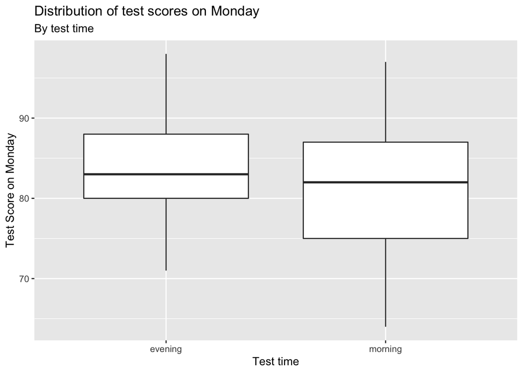

```r
ggplot(data = filtered) +
  geom_boxplot(aes(x = test_time_fixed, y = test_score_monday)) +
  labs(x = "Test time", y = "Test Score on Monday", title = "Distribution of test scores on Monday", subtitle = "By test time")
```

8. Combine all of your steps from (2) - (6) into a single block of code using pipes `%>%`.

```r
summary_df <- test_scores_raw %>%
  rename(test_score_monday = ttm,
         test_score_tuesday = ttt,
         test_score_wednesday = ttw) %>%
    select(id, test_score_monday, test_time) %>%
    mutate(test_time_fixed = if_else(test_time == "early", "morning", "evening")) %>%
    filter(!is.na(test_score_monday)) %>%
    group_by(test_time_fixed) %>%
    summarize(mean_monday = mean(test_score_monday, na.rm = TRUE),
            medidan_monday = median(test_score_monday, na.rm = TRUE),
            sd_monday = sd(test_score_monday, na.rm = TRUE))

summary_df
```

```
## # A tibble: 2 × 4
##   test_time_fixed mean_monday medidan_monday sd_monday
##   <chr>                 <dbl>          <dbl>     <dbl>
## 1 evening                83.5             83      5.93
## 2 morning                81.4             82      7.85
```

```r
# Clean dataset
clean_data = test_scores_raw %>%
  rename(test_score_monday = ttm,
         test_score_tuesday = ttt,
         test_score_wednesday = ttw) %>%
    select(id, test_score_monday, test_time) %>%
    mutate(test_time_fixed = if_else(test_time == "early", "morning", "evening")) %>%
    filter(!is.na(test_score_monday))

# Summary step next:
summary_df_2 = clean_data %>%
  group_by(test_time_fixed) %>%
  summarize(mean_monday = mean(test_score_monday),
            medidan_monday = median(test_score_monday),
            sd_monday = sd(test_score_monday))
```

9. Use a t-test (equal variances) to test whether mean Monday test scores significantly differ between morning and evening test-taking times, at a level of significance of 5%. Report your conclusion with the test-statistic, degrees of freedom, and p-value in a sentence using in-line R code.

```r
#equal variance assumption (not unequal)
monday_t_res = t.test(test_score_monday ~ test_time_fixed, data = clean_data,
                       var.equal = TRUE)

monday_t_res
```

```
##
##  Two Sample t-test
##
## data:  test_score_monday by test_time_fixed
## t = 1.6696, df = 112, p-value = 0.0978
## alternative hypothesis: true difference in means between group evening and group morning is not equal to 0
## 95 percent confidence interval:
##  -0.4062882  4.7571654
## sample estimates:
## mean in group evening mean in group morning
##              83.54386              81.36842
```

```r
tstat = round(monday_t_res$statistic, 2)
df = round(monday_t_res$parameter, 1)
p = round(monday_t_res$p.value, 3)
```

There is not enough evidence to reject the null hypothesis; the data do not support the alternative hypothesis that there is a significant difference in mean test scores between those who took the test in the morning and those who took the test in the evening on Monday (t = 1.67; df = 112; p = 0.098), at a level of significance of 5%.